# My visual data story of my weekly walking steps

## My visual story

This visual story is where I want to see what can I find through my walking steps reflect to my real life, all data has been collected alone through the walk steps records from Apple health(app).

## Weekly Average Steps

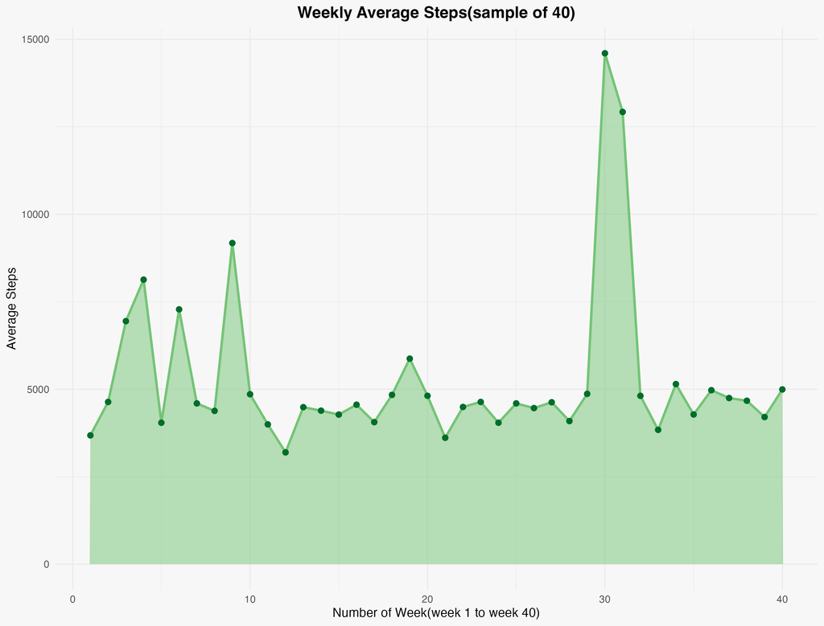

The first plot where I am using the geom_line to create the plot to analyzing the the mean weekly steps through a total number of 40 sample size which is relate to my real life. Firstly, we can see most of the average steps is somewhere around 4k to 5k, and some of the peaks seems a bit unusual. To relate to my uni-life, the first 10 weeks that was during the holiday where school haven’t start yet. Therefore, the trends goes like up and down which I hang out a week then have rest few days repeat like this pattern. Then, unfortunately, the school starts, by the I plot its easy to tell that I am not that energetic anymore, the ave weekly walking steps decreasing to a constant line to a interval[4k , 5k], with a fewer number of high ave walk steps. Moreover, the highest number of AVERAGE weekly steps which almost 15k. That was the the term-break, I went to hiking with my mates. At the end, back to normal.

## Who?(day) IS THE WINNER!

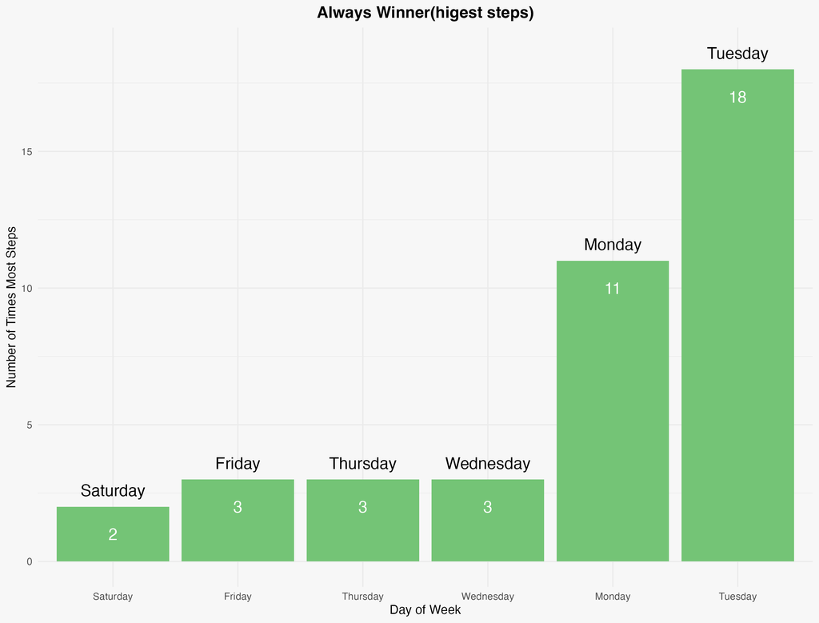

This bar plot counts the which day have the most numbers of steps in a week always in a ascending order through 40 sample sizes. To interrupt this, we see Tuesday is the always winner, then Monday. Here is one interesting thing, there is no Sunday which shows through out 40 weeks of sample, Sunday never win even once. Link to my timetable, Tuesday where I have the number of classes then Monday. There are couple reasons that causes this bar plot. My personal pattern goes like the beginning of the week, I always determined to study more harder, after two day’s “torturing”, my determination failed. Became lazy, watch recordings at home instead of go to campus. Then the weekend, on Sunday, an important reason is never win because that’s the day I catch up all the new topics learned by the week, where also my determination of hard-working is reborn( I cannot do this anymore, I must study hard and go to campus, not leave all works to one singe day.

## Step Distribution: Weeday vs Weekend

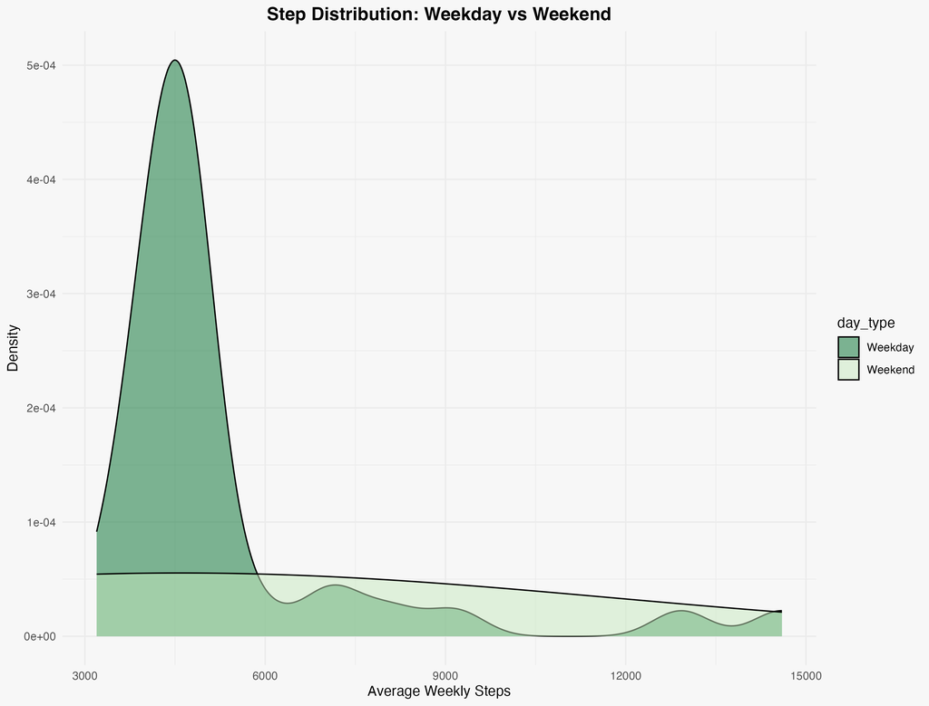

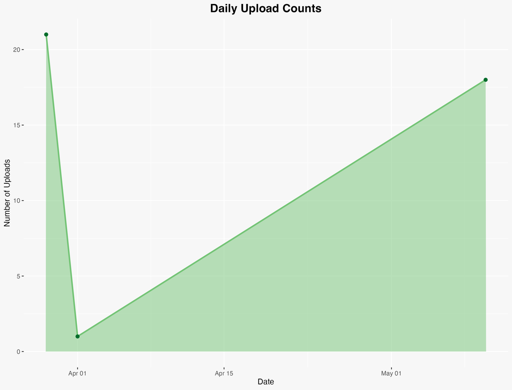

This plot is related by the time of date when the data have been uploaded, it is unuseful since the data has been collected on three days, that not gonna give any useful information to my visual story where 40 weeks of sample. Therefore, I did not do anything further.